# Small Proportions and Confidence Intervals Analysis

Áine Glynn

Filip Kłosowski

University of Galway

2026-05-12

# 1 Introduction

Often in clinical trials, particularly those assessing safety or adverse events, the proportions of interest are small. For instance, outcomes such as device failure may occur only in a small fraction of patients. This leads to estimated proportions close to 0 (and sometimes close to 1 for high success rates), which creates challenges for standard confidence interval methods.

The Wald interval — commonly introduced in basic statistical settings — is known to perform poorly in these scenarios:

$$\hat{p} \;\pm\; z_{1-\alpha/2}\sqrt{\frac{\hat{p}(1-\hat{p})}{n}}$$

This is because the distribution of $\hat{p}$ is highly skewed when $p$ is near 0 or 1, which violates the symmetry assumption underlying the normal approximation. As a result, the intervals can be too narrow, may extend beyond the $[0,1]$ range, and may exhibit substantial **undercoverage** — meaning the true proportion is contained within the interval less frequently than the nominal confidence level would suggest. This is particularly problematic in a clinical context where accurate uncertainty quantification is essential.

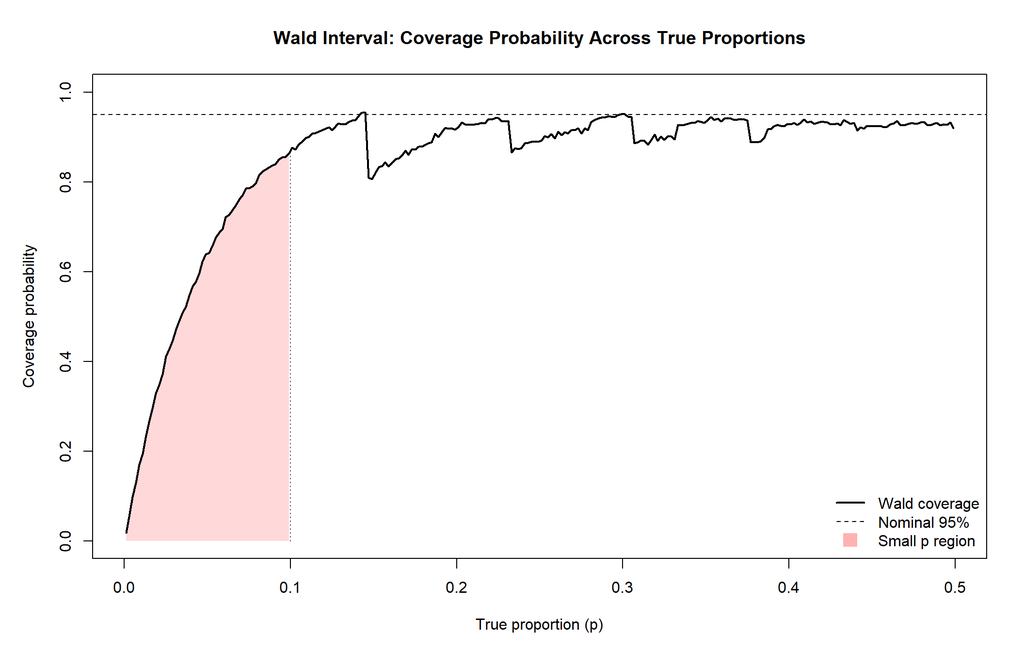

Wald interval coverage across a range of true proportions when n = 20. For small values of p (shaded region), coverage falls well below 95%, indicating poor performance of the normal approximation in this setting.

# 2 Single-Proportion vs Two-Proportion Settings

A key distinction in clinical trial design is whether the analysis involves a **single proportion** or a **comparison between two proportions**.

In performance goal studies — such as single-arm trials — the objective is to estimate a single proportion $p_T$ and compare it against a predefined benchmark $p_0$ derived from historical data or prior studies. Inference is based on constructing a confidence interval for $p_T$ and assessing whether it exceeds the performance threshold.

In contrast, **non-inferiority trials** involve a direct comparison between two groups, usually a treatment and a control. The parameter of interest is the difference $p_T - p_C$, and the goal is to determine whether the new treatment is not unacceptably worse than the control by more than a predefined margin $\Delta$. This requires confidence intervals for differences in proportions, introducing additional complexity.

This distinction is important because the issues highlighted with the Wald interval arise in both settings. The focus in this discussion is on confidence intervals for a **single proportion**, while noting that extensions to two-sample settings require different methodological approaches.

# 3 Alternative Methods

## 3.1 Wilson Score Interval

The Wilson score interval is based on inverting a score test rather than relying directly on a normal approximation. Unlike the Wald interval, it is not centred exactly at $\hat{p}$, which allows it to better account for the asymmetry present when proportions are small:

$$\frac{
\hat{p} + \dfrac{z^2}{2n}
\;\pm\;
z \sqrt{
\dfrac{\hat{p}(1 - \hat{p})}{n} + \dfrac{z^2}{4n^2}
}
}{
1 + \dfrac{z^2}{n}
}$$

## 3.2 Agresti–Coull Interval

A closely related approach, the Agresti–Coull interval applies a simple adjustment by adding approximately four pseudo-observations (two successes and two failures for a 95% confidence level). As discussed by Brown, Cai and DasGupta (2001), this results in intervals that are slightly more conservative while maintaining good overall performance:

$$\tilde{p} = \frac{x + z^2/2}{n + z^2}
\qquad
\tilde{p} \;\pm\; z_{1-\alpha/2} \sqrt{\frac{\tilde{p}(1 - \tilde{p})}{n
+ z^2}}$$

## 3.3 Clopper–Pearson Interval

The Clopper–Pearson interval takes a different approach, derived directly from the exact binomial distribution rather than relying on asymptotic approximations. As a result, it **guarantees** that the true proportion is contained within the interval at least as often as the nominal confidence level. However, this comes at the cost of conservativeness, particularly for small sample sizes or extreme proportions, leading to intervals that are typically wider than necessary in practice:

$$\left[
\mathrm{Beta}^{-1}\!\left(\tfrac{\alpha}{2};\; x,\; n - x + 1\right),
\;\;
\mathrm{Beta}^{-1}\!\left(1 - \tfrac{\alpha}{2};\; x + 1,\; n - x\right)
\right]$$

## 3.4 Prop.test Interval

The `prop.test` interval is based on a score-type method derived from a chi-squared approximation and is closely related to the Wilson interval. It typically includes a continuity correction — a small adjustment used when approximating discrete binomial data with a continuous distribution — so it is not identical in form. In practice it tends to show similar behaviour to the Wilson interval, particularly in terms of coverage:

$$\text{derived from a score test:}
\quad
\frac{(\hat{p} - p)^2}{\hat{p}(1-\hat{p})/n}$$

## 3.5 Jeffreys Interval

The Jeffreys interval is derived from a Bayesian framework using a $\mathrm{Beta}(0.5, 0.5)$ prior. Despite its Bayesian origin, it has been shown to have good frequentist properties, with coverage and interval width comparable to the Wilson interval, especially for small sample sizes and extreme proportions:

$$\left[
\mathrm{Beta}^{-1}\!\left(\tfrac{\alpha}{2};\; x + \tfrac{1}{2},\; n - x
+ \tfrac{1}{2}\right),
\;\;
\mathrm{Beta}^{-1}\!\left(1 - \tfrac{\alpha}{2};\; x + \tfrac{1}{2},\; n
- x + \tfrac{1}{2}\right)
\right]$$

While these methods are based on different underlying ideas, they lead to intervals with differing coverage properties and widths, particularly in settings involving small proportions.

# 4 Simulation Study

This simulation follows the comparative framework of Pires and Amado (2008), restricted to the most practically relevant methods: **Wald, Wilson, Agresti–Coull, Clopper–Pearson, prop.test** and **Jeffreys**. Since the focus is on small event rates, $p$ was evaluated over a grid of values near 0, with methods compared using coverage probability, expected interval width and minimum coverage.

```r
# ============================================================
# FUNCTION: coverage_plot_binom()
#
# Computes and plots coverage probability (CP) for selected
# binomial CI methods across a grid of true proportions.
# ============================================================

coverage_plot_binom <- function(n          = 50,
                                p_grid     = seq(0.001, 0.2, by = 0.001),
                                methods    = c("exact", "asymptotic", "agresti-coull",
                                               "wilson", "prop.test", "jeffreys"),
                                conf.level = 0.95,
                                plot       = TRUE) {

  if (!requireNamespace("binom", quietly = TRUE)) stop("Package 'binom' is required.")

  get_ci <- function(x, n, method, conf.level) {
    alpha <- 1 - conf.level
    if (method == "jeffreys") {
      lower <- ifelse(x == 0, 0, qbeta(alpha / 2,       x + 0.5, n - x + 0.5))
      upper <- ifelse(x == n, 1, qbeta(1 - alpha / 2,   x + 0.5, n - x + 0.5))
      data.frame(lower = lower, upper = upper)
    } else {
      ci <- binom::binom.confint(x, n, conf.level = conf.level, methods = method)
      data.frame(lower = ci$lower, upper = ci$upper)
    }
  }

  compute_coverage <- function(method) {
    coverage <- numeric(length(p_grid))
    for (i in seq_along(p_grid)) {
      p      <- p_grid[i]
      x_vals <- 0:n
      probs  <- dbinom(x_vals, size = n, prob = p)
      ci     <- get_ci(x_vals, n, method, conf.level)
      inside <- (ci$lower <= p) & (ci$upper >= p)
      coverage[i] <- sum(probs * inside)
    }
    data.frame(p = p_grid, coverage = coverage, method = method)
  }

  results <- do.call(rbind, lapply(methods, compute_coverage))

  method_labels <- c(
    "exact"         = "Clopper–Pearson",
    "asymptotic"    = "Wald",
    "agresti-coull" = "Agresti–Coull",
    "wilson"        = "Wilson",
    "prop.test"     = "Prop.test",
    "jeffreys"      = "Jeffreys"
  )

  results$method <- factor(
    results$method,
    levels = names(method_labels),
    labels = method_labels[names(method_labels) %in% methods]
  )

  if (plot) {
    n_methods <- length(unique(results$method))
    layout    <- if (n_methods <= 4) c(2, 2) else c(2, 3)
    par(mfrow = layout, mar = c(3, 3, 2.5, 1), oma = c(2, 2, 2, 1))

    for (m in levels(results$method)) {
      dat <- results[results$method == m, ]
      plot(dat$p, dat$coverage,
           type = "l", lwd = 1.8, col = "#2c7bb6",
           main = m, xlab = "", ylab = "",
           ylim = range(c(dat$coverage, conf.level)))
      abline(h = conf.level, lty = "dashed", col = "firebrick")
    }
    mtext("True proportion (p)",  side = 1, outer = TRUE, line = 0.5)
    mtext("Coverage probability", side = 2, outer = TRUE, line = 0.5)
    mtext(paste0("Coverage probability by method  |  n = ", n, ",  α = ", 1 - conf.level),
          side = 3, outer = TRUE, line = 0.5, font = 2)
  }

  invisible(results)
}
```

## 4.1 Coverage Probability vs True Proportion

### 4.1.1 n = 50

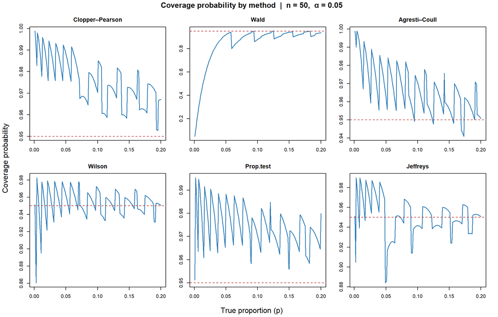

Coverage probability for each method as a function of p (n = 50, α = 0.05). The dashed red line marks the nominal 95% level. The Wald interval shows clear undercoverage for small p, whereas Clopper–Pearson remains above 95% throughout. Agresti–Coull and prop.test stay relatively stable, while Wilson and Jeffreys show some variation at very small p.

### 4.1.2 n = 200

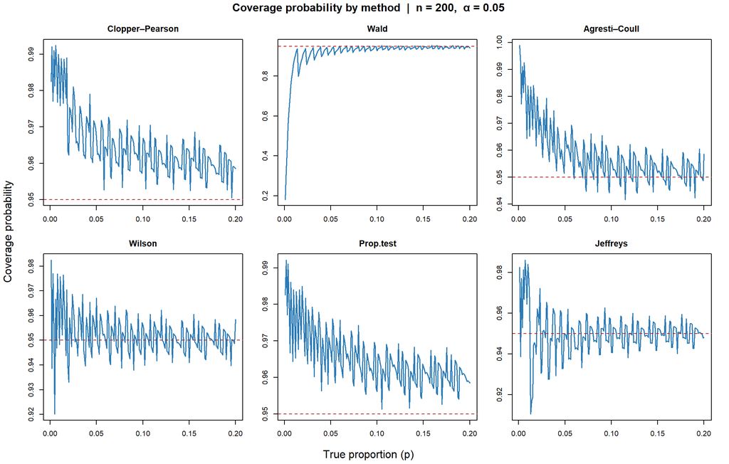

Coverage probability for each method as a function of p (n = 200, α = 0.05). The dashed red line marks the nominal 95% level. The Wald interval continues to perform poorly for small proportions. Clopper–Pearson remains conservative, while the other methods fluctuate around the nominal level with some instability at the lower range of p.

## 4.2 Minimum Coverage Probability vs Sample Size

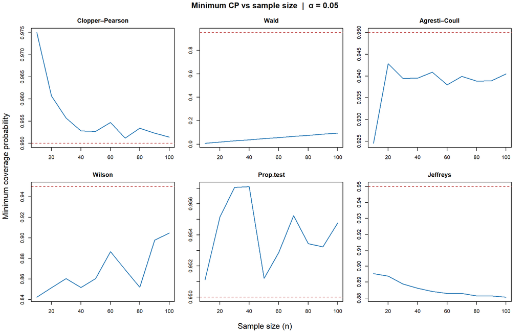

```r
# ============================================================
# FUNCTION: min_cp_vs_n_binom()
#
# Computes and plots the minimum coverage probability for
# selected CI methods across a range of sample sizes.
# ============================================================

min_cp_vs_n_binom <- function(n_grid     = seq(10, 100, by = 10),
                              p_grid     = seq(0.001, 0.2, by = 0.001),
                              methods    = c("exact", "asymptotic", "agresti-coull",
                                             "wilson", "prop.test", "jeffreys"),
                              conf.level = 0.95,
                              plot       = TRUE) {

  if (!requireNamespace("binom", quietly = TRUE)) stop("Package 'binom' is required.")

  get_ci <- function(x, n, method, conf.level) {
    alpha <- 1 - conf.level
    if (method == "jeffreys") {
      lower <- ifelse(x == 0, 0, qbeta(alpha / 2,     x + 0.5, n - x + 0.5))
      upper <- ifelse(x == n, 1, qbeta(1 - alpha / 2, x + 0.5, n - x + 0.5))
      data.frame(lower = lower, upper = upper)
    } else {
      ci <- binom::binom.confint(x, n, conf.level = conf.level, methods = method)
      data.frame(lower = ci$lower, upper = ci$upper)
    }
  }

  compute_min_cp <- function(method) {
    min_cp_vals <- numeric(length(n_grid))
    for (j in seq_along(n_grid)) {
      n        <- n_grid[j]
      coverage <- numeric(length(p_grid))
      for (i in seq_along(p_grid)) {
        p      <- p_grid[i]
        x_vals <- 0:n
        probs  <- dbinom(x_vals, size = n, prob = p)
        ci     <- get_ci(x_vals, n, method, conf.level)
        inside <- (ci$lower <= p) & (ci$upper >= p)
        coverage[i] <- sum(probs * inside)
      }
      min_cp_vals[j] <- min(coverage)
    }
    data.frame(n = n_grid, min_cp = min_cp_vals, method = method)
  }

  results <- do.call(rbind, lapply(methods, compute_min_cp))

  method_labels <- c(
    "exact"         = "Clopper–Pearson",
    "asymptotic"    = "Wald",
    "agresti-coull" = "Agresti–Coull",
    "wilson"        = "Wilson",
    "prop.test"     = "Prop.test",
    "jeffreys"      = "Jeffreys"
  )

  results$method <- factor(results$method,
                           levels = methods,
                           labels = method_labels[methods])

  if (plot) {
    n_methods <- length(methods)
    layout    <- if (n_methods <= 4) c(2, 2) else c(2, 3)
    par(mfrow = layout, mar = c(3, 3, 2.5, 1), oma = c(2, 2, 2, 1))
    for (m in levels(results$method)) {
      dat <- results[results$method == m, ]
      plot(dat$n, dat$min_cp,
           type = "l", lwd = 1.8, col = "#2c7bb6",
           main = m, xlab = "", ylab = "",
           ylim = range(c(dat$min_cp, conf.level)))
      abline(h = conf.level, lty = "dashed", col = "firebrick")
    }
    mtext("Sample size (n)",              side = 1, outer = TRUE, line = 0.5)
    mtext("Minimum coverage probability", side = 2, outer = TRUE, line = 0.5)
    mtext("Minimum CP vs sample size  |  α = 0.05",
          side = 3, outer = TRUE, line = 0.5, font = 2)
  }

  invisible(results)
}
```

## 4.3 Expected Interval Width

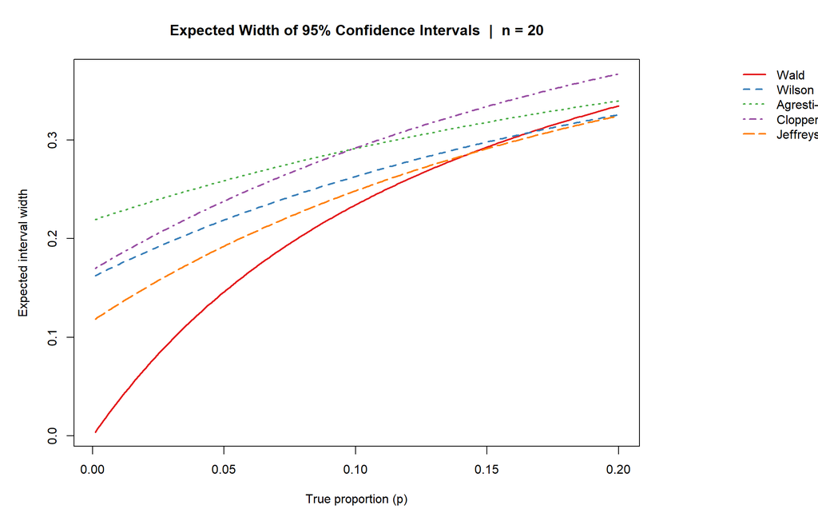

```r
# ============================================================
# FUNCTION: expected_width_vs_p_binom()
#
# Computes and plots expected CI width for selected methods
# across a range of true p values, weighted by binomial
# probability of each outcome.
# ============================================================

expected_width_vs_p_binom <- function(n          = 20,
                                      p_grid     = seq(0.001, 0.2, by = 0.001),
                                      methods    = c("asymptotic", "wilson",
                                                     "agresti-coull", "exact", "jeffreys"),
                                      conf.level = 0.95,
                                      plot       = TRUE) {

  if (!requireNamespace("binom", quietly = TRUE)) stop("Package 'binom' is required.")

  get_ci <- function(x, n, method, conf.level) {
    alpha <- 1 - conf.level
    if (method == "jeffreys") {
      lower <- ifelse(x == 0, 0, qbeta(alpha / 2,     x + 0.5, n - x + 0.5))
      upper <- ifelse(x == n, 1, qbeta(1 - alpha / 2, x + 0.5, n - x + 0.5))
      data.frame(lower = lower, upper = upper)
    } else {
      ci <- binom::binom.confint(x, n, conf.level = conf.level, methods = method)
      data.frame(lower = ci$lower, upper = ci$upper)
    }
  }

  compute_width <- function(method) {
    exp_width <- numeric(length(p_grid))
    for (i in seq_along(p_grid)) {
      p      <- p_grid[i]
      x_vals <- 0:n
      probs  <- dbinom(x_vals, size = n, prob = p)
      ci     <- get_ci(x_vals, n, method, conf.level)
      widths <- ci$upper - ci$lower
      exp_width[i] <- sum(probs * widths)
    }
    data.frame(p = p_grid, expected_width = exp_width, method = method)
  }

  results <- do.call(rbind, lapply(methods, compute_width))

  method_labels <- c(
    "asymptotic"    = "Wald",
    "wilson"        = "Wilson",
    "agresti-coull" = "Agresti–Coull",
    "exact"         = "Clopper–Pearson",
    "jeffreys"      = "Jeffreys"
  )

  results$method <- factor(results$method,
                           levels = methods,
                           labels = method_labels[methods])

  if (plot) {
    method_cols <- c("#e41a1c", "#377eb8", "#4daf4a", "#984ea3", "#ff7f00")
    par(mar = c(5, 5, 4, 12), xpd = TRUE)

    plot(NA, NA,
         xlim = range(p_grid),
         ylim = range(results$expected_width),
         xlab = "True proportion (p)",
         ylab = "Expected interval width",
         main = paste0("Expected Width of ", round(conf.level * 100), "% Confidence Intervals  |  n = ", n))

    for (i in seq_along(levels(results$method))) {
      m   <- levels(results$method)[i]
      dat <- results[results$method == m, ]
      lines(dat$p, dat$expected_width,
            lwd = 2, lty = i, col = method_cols[i])
    }

    legend("topright", inset = c(-0.42, 0),
           legend = levels(results$method),
           lwd = 2, lty = seq_along(levels(results$method)),
           col = method_cols, bty = "n")
  }

  invisible(results)
}
```

# 5 Discussion

The minimum coverage plots clearly show that the **Wald interval** performs very poorly — with coverage well below the nominal 95% level, especially for smaller sample sizes — and is not suitable for this setting.

The **Clopper–Pearson interval** consistently stays above the nominal level, which reflects its conservative nature. While this guarantees that the stated confidence level is not violated, it comes at the cost of producing unnecessarily wide intervals.

The coverage probability plots against the true proportion $p$ tell a similar story. The Wald interval has very poor coverage for small values of $p$, and Clopper–Pearson again remains above the nominal level across the full range. The Agresti–Coull and prop.test intervals behave more consistently around the 95% level, while the Wilson and Jeffreys intervals show some variability at very small $p$ but remain reasonably close to the target overall.

Overall, these findings are consistent with what has been reported in the literature. The poor performance of the Wald interval and the conservative behaviour of the Clopper–Pearson interval are well established, while methods such as **Wilson, Agresti–Coull and Jeffreys** are generally recommended as more reliable alternatives when dealing with small proportions.

## 5.1 A Note on Agresti–Coull in Practice

Although the Agresti–Coull interval appears to be a strong choice based on this simulation study, it is often less preferred than the Wilson interval in practice. The Agresti–Coull can be viewed as a simplified approximation to the Wilson score interval (Agresti and Coull, 1998). Both methods shift the centre away from $\hat{p}$, but the Agresti–Coull adjustment typically produces intervals that are slightly wider.

As discussed by Brown, Cai and DasGupta (2001), while Agresti–Coull performs well in terms of coverage, the **Wilson interval is generally preferred** due to its stronger theoretical justification and greater efficiency — achieving similar coverage with narrower intervals. This is particularly important in performance goal settings, where narrower intervals provide more precise estimates and increase the ability to demonstrate that the target performance has been met.

# 6 References

Agresti, A. and Coull, B.A. (1998) Approximate is better than “exact” for interval estimation of binomial proportions. *The American Statistician*, 52(2), pp. 119–126.

Brown, L.D., Cai, T.T. and DasGupta, A. (2001) Confidence intervals for a binomial proportion and asymptotic expansions. *Statistical Science*, 16(2), pp. 101–133.

Pires, A.M. and Amado, C. (2008) Interval estimators for a binomial proportion: Comparison of twenty methods. *REVSTAT – Statistical Journal*, 6(2), pp. 165–197. Available at: https://revstat.ine.pt/index.php/REVSTAT/article/view/63/67

Dorai-Raj, S. (2023) *binom: Binomial Confidence Intervals For Several Parameterizations*. R package version. Available at: https://cran.r-project.org/package=binom